# Supervised Learning - Foundations Project: ReCell

#### Observation

- The top two brands with the highest number of big screens (i.e., larger than 6 inches) is Huawei and Samsung.
1. A lot of devices nowadays offer great selfie cameras, allowing us to capture our favorite moments with loved ones. What is the distribution of devices offering greater than 8MP selfie cameras across brands?

```python
selfie_greater_8MP_df = df[df['selfie_camera_mp'] > 8]

print (F"There are {selfie_greater_8MP_df.shape[0]} phones that have a selfie camera with more than 8 MP.")
```

```
There are 655 phones that have a selfie camera with more than 8 MP.
```

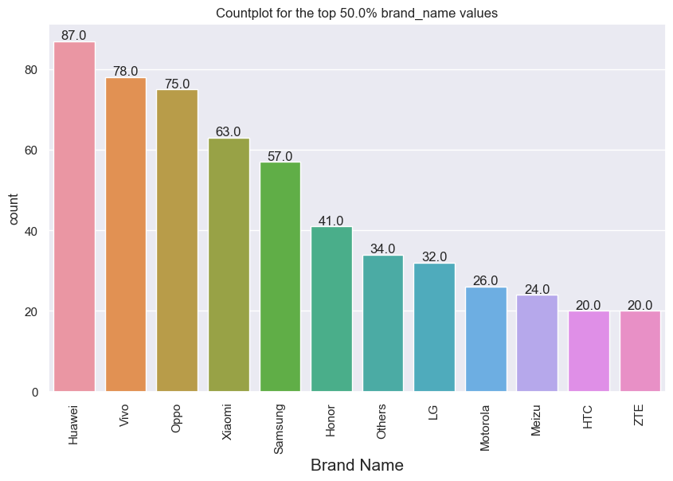

```
Number of brand names with a large selfie camera: 25
```

```python
#Create histogram plot for the top groups
countplot(selfie_greater_8MP_df,'brand_name',show_perc=.5,label_count=True)

#Print the total number of unique restaurants
print(f"Number of brand names with a large selfie camera: {selfie_greater_8MP_df['brand_name'].nunique()}")
```

#### Observation

- The top 5 brands with a large selfie camera (greater than 8 MP) is: Huawei, Vivo, Oppo, Xiaomi, and Samsung
1. Which attributes are highly correlated with the normalized price of a used device?

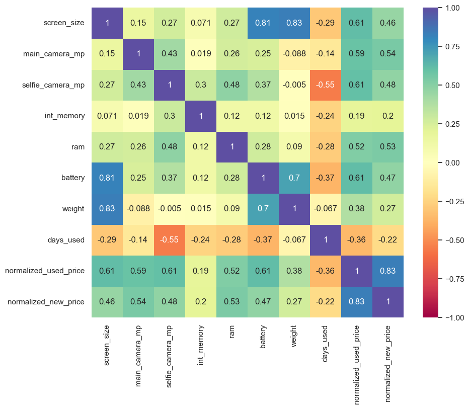

```python
# Get the list of columns that are numbers
col_list = df.select_dtypes(include=np.number).columns.tolist()

# dropping release_year as it's not really continuous in nature
col_list.remove("release_year")

# show a heatmap to look for any strong correlations between the number fields.
heatmap(df[col_list])
```

#### Observation

- normalized_new_price is highly correlated with normalized_used_price.
- screen_size, main_camera_mp, selfie_camera_mp, and battery and only slightly correlated.

## Data Preprocessing

- Missing value treatment
- Feature engineering (if needed)
- Outlier detection and treatment (if needed)
- Preparing data for modeling
- Any other preprocessing steps (if needed)

#### Missing Value Treatment

```python
#Make a copy of DataFrame before we start imputing
df_copy = df.copy()
df_copy.head()
```

|  | brand_name | os | screen_size | 4g | 5g | main_camera_mp | selfie_camera_mp | int_memory | ram | battery | weight | release_year | days_used | normalized_used_price | normalized_new_price |
| --- | --- | --- | --- | --- | --- | --- | --- | --- | --- | --- | --- | --- | --- | --- | --- |
| 0 | Honor | Android | 14.500000 | yes | no | 13.000000 | 5.000000 | 64.000000 | 3.000000 | 3020.000000 | 146.000000 | 2020 | 127 | 4.307572 | 4.715100 |
| 1 | Honor | Android | 17.300000 | yes | yes | 13.000000 | 16.000000 | 128.000000 | 8.000000 | 4300.000000 | 213.000000 | 2020 | 325 | 5.162097 | 5.519018 |
| 2 | Honor | Android | 16.690000 | yes | yes | 13.000000 | 8.000000 | 128.000000 | 8.000000 | 4200.000000 | 213.000000 | 2020 | 162 | 5.111084 | 5.884631 |
| 3 | Honor | Android | 25.500000 | yes | yes | 13.000000 | 8.000000 | 64.000000 | 6.000000 | 7250.000000 | 480.000000 | 2020 | 345 | 5.135387 | 5.630961 |
| 4 | Honor | Android | 15.320000 | yes | no | 13.000000 | 8.000000 | 64.000000 | 3.000000 | 5000.000000 | 185.000000 | 2020 | 293 | 4.389995 | 4.947837 |

```python
# Rerun the null check by field
print(df_copy.isnull().sum())
```

```
brand_name                 0
os                         0
screen_size                0
4g                         0
5g                         0
main_camera_mp           179
selfie_camera_mp           2
int_memory                 4
ram                        4
battery                    6
weight                     7
release_year               0
days_used                  0
normalized_used_price      0
normalized_new_price       0
dtype: int64
```

```python
#Let's tackle the field with the most null values: main_camera_mp
blank_main_camera_rows = df_copy[df_copy['main_camera_mp'].isnull()]

#Calculate value counts by brand
print (blank_main_camera_rows['brand_name'].value_counts())
print ("\n")

#Group by release year and brand
print("Group by release_year and then brand_name")
print(blank_main_camera_rows.groupby('release_year')['brand_name'].value_counts())
```

```
brand_name
Realme        36
Xiaomi        23
Oppo          20
Motorola      18
OnePlus       17
Meizu         15
Vivo          14
Infinix       10
Sony           7
ZTE            4
Asus           4
BlackBerry     4
Coolpad        3
Lava           2
Panasonic      2
Name: count, dtype: int64


Group by release_year and then brand_name
release_year  brand_name
2017          OnePlus        2
2018          BlackBerry     4
              OnePlus        3
              Panasonic      2
              Coolpad        1
2019          Realme        12
              Meizu         11
              OnePlus        8
              Sony           5
              Infinix        4
              Asus           4
              Coolpad        1
2020          Realme        24
              Xiaomi        23
              Oppo          20
              Motorola      18
              Vivo          14
              Infinix        6
              Meizu          4
              ZTE            4
              OnePlus        4
              Sony           2
              Lava           2
              Coolpad        1
Name: count, dtype: int64
```

```python
#Impute the missing values in main_camera_mp with the median values for that particular release year and brand.
df_copy['main_camera_mp'] = df_copy['main_camera_mp'].fillna(
    value=df_copy.groupby(['release_year','brand_name'])['main_camera_mp'].transform("median"))

# Rerun the null check by field
print(df_copy.isnull().sum())
```

```
brand_name                 0
os                         0
screen_size                0
4g                         0
5g                         0
main_camera_mp           179
selfie_camera_mp           2
int_memory                 4
ram                        4
battery                    6
weight                     7
release_year               0
days_used                  0
normalized_used_price      0
normalized_new_price       0
dtype: int64
```

#### Observation

- The number of missing values remained the same for main_camera_mp. This may be an indication for those years and brand all values are missing and the medians were zero.
- Will now impute by increasing our `group by` to just brand_name

```python
#Impute the missing values in main_camera_mp with the median values for that particular release year and brand.
df_copy['main_camera_mp'] = df_copy['main_camera_mp'].fillna(
    value=df_copy.groupby(['brand_name'])['main_camera_mp'].transform("median"))

# Rerun the null check by field
print(df_copy.isnull().sum())
```

```
brand_name                0
os                        0
screen_size               0
4g                        0
5g                        0
main_camera_mp           10
selfie_camera_mp          2
int_memory                4
ram                       4
battery                   6
weight                    7
release_year              0
days_used                 0
normalized_used_price     0
normalized_new_price      0
dtype: int64
```

```python
# Let's now imput the remaining 10 values by the median of the entire set
df_copy["main_camera_mp"] = df_copy["main_camera_mp"].fillna(df_copy["main_camera_mp"].median())

# checking for missing values
df_copy.isnull().sum()
```

```
brand_name               0
os                       0
screen_size              0
4g                       0
5g                       0
main_camera_mp           0
selfie_camera_mp         2
int_memory               4
ram                      4
battery                  6
weight                   7
release_year             0
days_used                0
normalized_used_price    0
normalized_new_price     0
dtype: int64
```

```python
# Let's now use what we learned from main_camera_mp and come up with a more efficient approach to tackle the remaining features.
features_to_impute = ['selfie_camera_mp','int_memory','ram','battery','weight']

#Impute the missing values in main_camera_mp with the median values for that particular release year and brand.
for feature in features_to_impute:
    df_copy[feature] = df_copy[feature].fillna(
        value=df_copy.groupby(['release_year','brand_name'])[feature].transform("median"))

# checking for missing values
print(df_copy.isnull().sum())
```

```
brand_name               0
os                       0
screen_size              0
4g                       0
5g                       0
main_camera_mp           0
selfie_camera_mp         2
int_memory               0
ram                      0
battery                  6
weight                   7
release_year             0
days_used                0
normalized_used_price    0
normalized_new_price     0
dtype: int64
```

```python
# Let's now use what we learned from main_camera_mp and come up with a more efficient approach to tackle the remaining features.
features_to_impute = ['selfie_camera_mp','battery','weight']

#Impute the missing values in main_camera_mp with the median values for that particular brand.
for feature in features_to_impute:
    df_copy[feature] = df_copy[feature].fillna(
        value=df_copy.groupby(['brand_name'])[feature].transform("median"))

# checking for missing values
print(df_copy.isnull().sum())
```

```
brand_name               0
os                       0
screen_size              0
4g                       0
5g                       0
main_camera_mp           0
selfie_camera_mp         0
int_memory               0
ram                      0
battery                  0
weight                   0
release_year             0
days_used                0
normalized_used_price    0
normalized_new_price     0
dtype: int64
```

#### Observations

- All features have now been imputed, using the median, and all have values now.

#### Feature Engineering (if needed)

- Let's convert `release_year` to a more continuous number.
- Create a new column `years_since_release` from the `release_year` column.
- Use 2021 (date data was collected) as the baseline.
- Then drop the `release_year` column.

```python
# Create a new column years_since_release
df_copy["years_since_release"] = 2021 - df_copy["release_year"]

# Drop the original release_year column from the data set
df_copy.drop("release_year", axis=1, inplace=True)

# Print out some useful information on years_since_release
df_copy["years_since_release"].describe()
print (df_copy.head(5))
```

```
  brand_name       os  screen_size   4g   5g  main_camera_mp  \
0      Honor  Android    14.500000  yes   no       13.000000
1      Honor  Android    17.300000  yes  yes       13.000000
2      Honor  Android    16.690000  yes  yes       13.000000
3      Honor  Android    25.500000  yes  yes       13.000000
4      Honor  Android    15.320000  yes   no       13.000000

   selfie_camera_mp  int_memory      ram     battery     weight  days_used  \
0          5.000000   64.000000 3.000000 3020.000000 146.000000        127
1         16.000000  128.000000 8.000000 4300.000000 213.000000        325
2          8.000000  128.000000 8.000000 4200.000000 213.000000        162
3          8.000000   64.000000 6.000000 7250.000000 480.000000        345
4          8.000000   64.000000 3.000000 5000.000000 185.000000        293

   normalized_used_price  normalized_new_price  years_since_release
0               4.307572              4.715100                    1
1               5.162097              5.519018                    1
2               5.111084              5.884631                    1
3               5.135387              5.630961                    1
4               4.389995              4.947837                    1
```

#### Outlier detectionand treatment (if needed)

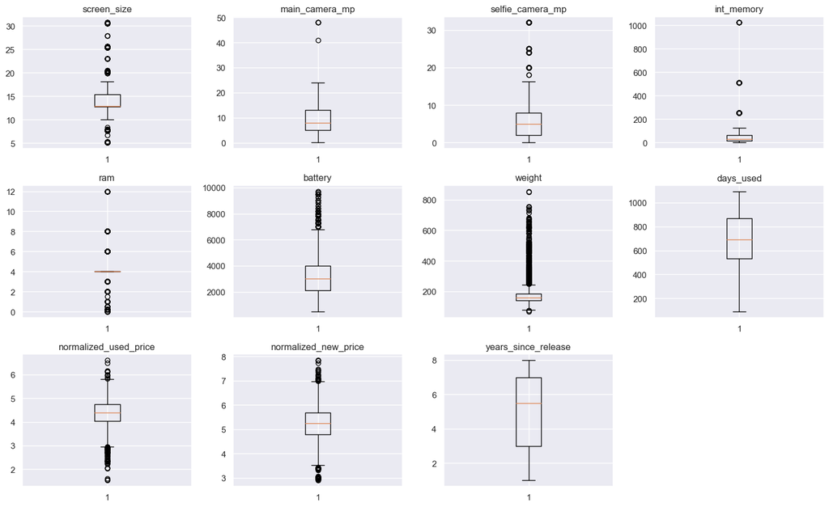

```python
# Following code base was extracted from GreatLearning Week 4 (Hands_on_Notebook_ExploratoryDataAnalysis)
# outlier detection using boxplot
# selecting the numerical columns where outliers were treated

# Get the list of columns that are numbers
numeric_columns = df_copy.select_dtypes(include=np.number).columns.tolist()

# Plot barplots for each of the numerical features
with warnings.catch_warnings():
    warnings.filterwarnings("ignore", message="The figure layout has changed to tight")

    plt.figure(figsize=(15, 12))

    for i, variable in enumerate(numeric_columns):
        plt.subplot(4, 4, i + 1)
        plt.boxplot(df_copy[variable], whis=1.5)
        plt.tight_layout()
        plt.title(variable)
    plt.show()
```

```python
# setting the limit for the number of displayed rows
pd.set_option("display.max_rows", 10) # To set row limits replace None with a number

# extracting the battery rows that are outliers beyond the maximum line.
# IQR= Q3-Q1=1900
# max_value = Q3 + 1.5IQR = 6850
df_copy.loc[df_copy['battery'] > 6850]
```

|  | brand_name | os | screen_size | 4g | 5g | main_camera_mp | selfie_camera_mp | int_memory | ram | battery | weight | days_used | normalized_used_price | normalized_new_price | years_since_release |
| --- | --- | --- | --- | --- | --- | --- | --- | --- | --- | --- | --- | --- | --- | --- | --- |
| 3 | Honor | Android | 25.500000 | yes | yes | 13.000000 | 8.000000 | 64.000000 | 6.000000 | 7250.000000 | 480.000000 | 345 | 5.135387 | 5.630961 | 1 |
| 33 | Huawei | Android | 25.500000 | yes | no | 8.000000 | 8.000000 | 64.000000 | 4.000000 | 7250.000000 | 450.000000 | 211 | 5.133089 | 5.518777 | 1 |
| 36 | Huawei | Android | 25.600000 | yes | yes | 13.000000 | 8.000000 | 128.000000 | 6.000000 | 7250.000000 | 460.000000 | 139 | 5.182457 | 6.310336 | 1 |
| 40 | Huawei | Android | 25.600000 | yes | no | 13.000000 | 8.000000 | 128.000000 | 6.000000 | 7250.000000 | 460.000000 | 256 | 4.997685 | 6.107268 | 2 |
| 49 | Huawei | Android | 25.600000 | yes | no | 13.000000 | 8.000000 | 64.000000 | 4.000000 | 7500.000000 | 498.000000 | 205 | 4.936630 | 5.704782 | 2 |
| ... | ... | ... | ... | ... | ... | ... | ... | ... | ... | ... | ... | ... | ... | ... | ... |
| 2588 | Samsung | Android | 25.430000 | no | no | 8.000000 | 2.000000 | 16.000000 | 4.000000 | 8220.000000 | 469.000000 | 920 | 4.741011 | 5.888545 | 7 |
| 2608 | Samsung | Android | 25.430000 | yes | no | 8.000000 | 2.000000 | 16.000000 | 4.000000 | 8220.000000 | 130.400000 | 971 | 4.773815 | 5.915582 | 8 |
| 2781 | Spice | Android | 25.400000 | no | no | 3.150000 | 0.300000 | 16.000000 | 4.000000 | 7600.000000 | 158.000000 | 917 | 4.391729 | 5.189283 | 8 |
| 2937 | Xiaomi | Android | 25.430000 | yes | no | 13.000000 | 5.000000 | 128.000000 | 4.000000 | 8620.000000 | 485.000000 | 665 | 5.116256 | 5.563063 | 3 |
| 3051 | Others | Android | 12.830000 | yes | no | 16.000000 | 8.000000 | 32.000000 | 4.000000 | 9000.000000 | 469.000000 | 621 | 4.938566 | 5.519900 | 3 |

77 rows × 15 columns

```python
# setting the limit for the number of displayed rows
pd.set_option("display.max_rows", 10) # To set row limits replace None with a number

# extracting the weight rows that have a large weight.
# IQR = Q3-Q1 = 185-142= 43
# max = Q3 + 1.5*IQR = 185 + 1.5*(43) = 249.5
df_copy.loc[df_copy['weight'] > 249.5]
```

|  | brand_name | os | screen_size | 4g | 5g | main_camera_mp | selfie_camera_mp | int_memory | ram | battery | weight | days_used | normalized_used_price | normalized_new_price | years_since_release |
| --- | --- | --- | --- | --- | --- | --- | --- | --- | --- | --- | --- | --- | --- | --- | --- |
| 3 | Honor | Android | 25.500000 | yes | yes | 13.000000 | 8.000000 | 64.000000 | 6.000000 | 7250.000000 | 480.000000 | 345 | 5.135387 | 5.630961 | 1 |
| 21 | Others | Android | 20.320000 | no | no | 8.000000 | 0.300000 | 16.000000 | 1.000000 | 5680.000000 | 453.600000 | 933 | 4.452136 | 5.484382 | 8 |
| 31 | Huawei | Android | 20.320000 | yes | no | 5.000000 | 2.000000 | 16.000000 | 2.000000 | 5100.000000 | 310.000000 | 231 | 4.170534 | 4.598246 | 1 |
| 33 | Huawei | Android | 25.500000 | yes | no | 8.000000 | 8.000000 | 64.000000 | 4.000000 | 7250.000000 | 450.000000 | 211 | 5.133089 | 5.518777 | 1 |
| 36 | Huawei | Android | 25.600000 | yes | yes | 13.000000 | 8.000000 | 128.000000 | 6.000000 | 7250.000000 | 460.000000 | 139 | 5.182457 | 6.310336 | 1 |
| ... | ... | ... | ... | ... | ... | ... | ... | ... | ... | ... | ... | ... | ... | ... | ... |
| 3278 | Others | Android | 15.320000 | yes | no | 2.000000 | 16.000000 | 128.000000 | 4.000000 | 5500.000000 | 290.000000 | 306 | 4.745106 | 5.507321 | 1 |
| 3279 | Others | Android | 15.320000 | yes | no | 8.000000 | 16.000000 | 128.000000 | 8.000000 | 5500.000000 | 290.000000 | 211 | 5.169063 | 5.777621 | 2 |
| 3304 | Xiaomi | Android | 17.810000 | yes | yes | 13.000000 | 20.000000 | 256.000000 | 8.000000 | 5000.000000 | 253.000000 | 361 | 5.223917 | 6.509499 | 1 |
| 3348 | Huawei | Android | 20.320000 | yes | yes | 10.500000 | 16.000000 | 512.000000 | 8.000000 | 4500.000000 | 300.000000 | 129 | 5.959251 | 7.847841 | 1 |
| 3436 | Samsung | Android | 17.860000 | yes | yes | 12.000000 | 9.000000 | 512.000000 | 12.000000 | 4235.000000 | 263.000000 | 434 | 5.573750 | 7.333016 | 2 |

365 rows × 15 columns

```python
# setting the limit for the number of displayed rows
pd.set_option("display.max_rows", 10) # To set row limits replace None with a number

# extracting the weight rows that have an unusually small amount of RAM.
df_copy.loc[df_copy['ram'] <= .02]
```

|  | brand_name | os | screen_size | 4g | 5g | main_camera_mp | selfie_camera_mp | int_memory | ram | battery | weight | days_used | normalized_used_price | normalized_new_price | years_since_release |
| --- | --- | --- | --- | --- | --- | --- | --- | --- | --- | --- | --- | --- | --- | --- | --- |
| 116 | Nokia | Others | 5.180000 | no | no | 0.300000 | 0.000000 | 0.060000 | 0.020000 | 1200.000000 | 88.200000 | 266 | 3.370738 | 3.699077 | 1 |
| 117 | Nokia | Others | 5.180000 | yes | no | 0.300000 | 0.000000 | 32.000000 | 0.020000 | 1200.000000 | 86.500000 | 234 | 2.721295 | 3.688379 | 2 |
| 2044 | Nokia | Others | 5.180000 | yes | no | 2.000000 | 0.000000 | 0.100000 | 0.020000 | 1100.000000 | 117.000000 | 417 | 3.916015 | 4.505681 | 3 |
| 2049 | Nokia | Others | 5.180000 | yes | no | 2.000000 | 0.000000 | 0.060000 | 0.020000 | 1200.000000 | 88.100000 | 582 | 3.559909 | 4.611252 | 3 |
| 2052 | Nokia | Others | 5.180000 | no | no | 2.000000 | 0.000000 | 0.100000 | 0.020000 | 1200.000000 | 88.200000 | 680 | 3.602504 | 4.256747 | 4 |
| ... | ... | ... | ... | ... | ... | ... | ... | ... | ... | ... | ... | ... | ... | ... | ... |
| 2092 | Nokia | Others | 7.620000 | no | no | 5.000000 | 0.000000 | 0.100000 | 0.020000 | 1010.000000 | 100.000000 | 1043 | 3.535728 | 4.370586 | 8 |
| 2098 | Nokia | Others | 5.180000 | no | no | 1.300000 | 0.000000 | 0.060000 | 0.020000 | 1020.000000 | 89.600000 | 955 | 4.035479 | 4.076011 | 8 |
| 2102 | Nokia | Others | 7.620000 | no | no | 3.150000 | 0.000000 | 0.060000 | 0.020000 | 1200.000000 | 98.200000 | 668 | 3.532518 | 4.382527 | 8 |
| 2106 | Nokia | Others | 5.180000 | no | no | 3.150000 | 0.000000 | 0.100000 | 0.020000 | 1110.000000 | 102.000000 | 1006 | 4.167595 | 4.237579 | 8 |
| 2107 | Nokia | Others | 7.620000 | no | no | 2.000000 | 0.000000 | 0.100000 | 0.020000 | 1110.000000 | 103.700000 | 660 | 3.295096 | 4.380025 | 8 |

19 rows × 15 columns

#### Observations

- There are quite a few outliers in the data
- The outliers will not be treated as they are proper values
  - Many of the outliers are due to tablets and larger phones.
  - There are some outliers due to basic phones that do not have much memory (but strong batteries) and are probably geared to older clientele that just need a phone, with a strong battery, for actual calling and basic text and are not needed for apps.

#### Preparing data for modeling

```python
# Create a new dataFrame for the independent variables by copying everything but the dependent variable.
X = df_copy.drop(["normalized_used_price"], axis=1)

# Create a new dataFrame for just the dependent feature: normalized_used_price
y = df_copy["normalized_used_price"]

# Verify X (Predictors) and Y (Target) have the correct columns
print (X.head(5))
print()
print(y.head(5))
```

```
  brand_name       os  screen_size   4g   5g  main_camera_mp  \
0      Honor  Android    14.500000  yes   no       13.000000
1      Honor  Android    17.300000  yes  yes       13.000000
2      Honor  Android    16.690000  yes  yes       13.000000
3      Honor  Android    25.500000  yes  yes       13.000000
4      Honor  Android    15.320000  yes   no       13.000000

   selfie_camera_mp  int_memory      ram     battery     weight  days_used  \
0          5.000000   64.000000 3.000000 3020.000000 146.000000        127
1         16.000000  128.000000 8.000000 4300.000000 213.000000        325
2          8.000000  128.000000 8.000000 4200.000000 213.000000        162
3          8.000000   64.000000 6.000000 7250.000000 480.000000        345
4          8.000000   64.000000 3.000000 5000.000000 185.000000        293

   normalized_new_price  years_since_release
0              4.715100                    1
1              5.519018                    1
2              5.884631                    1
3              5.630961                    1
4              4.947837                    1

0   4.307572
1   5.162097
2   5.111084
3   5.135387
4   4.389995
Name: normalized_used_price, dtype: float64
```

Any other preprocessing steps (if needed)

```python
#Add a constant for the Y-Intercept
X = sm.add_constant(X)

#Verify the constant was added
X.info()
```

```
<class 'pandas.core.frame.DataFrame'>
RangeIndex: 3454 entries, 0 to 3453
Data columns (total 15 columns):
 #   Column                Non-Null Count  Dtype
---  ------                --------------  -----
 0   const                 3454 non-null   float64
 1   brand_name            3454 non-null   object
 2   os                    3454 non-null   object
 3   screen_size           3454 non-null   float64
 4   4g                    3454 non-null   object
 5   5g                    3454 non-null   object
 6   main_camera_mp        3454 non-null   float64
 7   selfie_camera_mp      3454 non-null   float64
 8   int_memory            3454 non-null   float64
 9   ram                   3454 non-null   float64
 10  battery               3454 non-null   float64
 11  weight                3454 non-null   float64
 12  days_used             3454 non-null   int64
 13  normalized_new_price  3454 non-null   float64
 14  years_since_release   3454 non-null   int64
dtypes: float64(9), int64(2), object(4)
memory usage: 404.9+ KB
```

```python
#Create dummy columns for the category type columns.
#Also, drop the first column since it is redundant data and can be derived by the remaining dummy columns
X = pd.get_dummies(
    X,
    columns=X.select_dtypes(include=["object", "category"]).columns.tolist(),
    drop_first=True,
)

#Verify dummy columns are created
X.head()
```

|  | const | screen_size | main_camera_mp | selfie_camera_mp | int_memory | ram | battery | weight | days_used | normalized_new_price | years_since_release | brand_name_Alcatel | brand_name_Apple | brand_name_Asus | brand_name_BlackBerry | brand_name_Celkon | brand_name_Coolpad | brand_name_Gionee | brand_name_Google | brand_name_HTC | brand_name_Honor | brand_name_Huawei | brand_name_Infinix | brand_name_Karbonn | brand_name_LG | brand_name_Lava | brand_name_Lenovo | brand_name_Meizu | brand_name_Micromax | … |
| --- | --- | --- | --- | --- | --- | --- | --- | --- | --- | --- | --- | --- | --- | --- | --- | --- | --- | --- | --- | --- | --- | --- | --- | --- | --- | --- | --- | --- | --- | --- |
| 0 | 1.000000 | 14.500000 | 13.000000 | 5.000000 | 64.000000 | 3.000000 | 3020.000000 | 146.000000 | 127 | 4.715100 | 1 | False | False | False | False | False | False | False | False | False | True | False | False | False | False | False | False | False | False | … |
| 1 | 1.000000 | 17.300000 | 13.000000 | 16.000000 | 128.000000 | 8.000000 | 4300.000000 | 213.000000 | 325 | 5.519018 | 1 | False | False | False | False | False | False | False | False | False | True | False | False | False | False | False | False | False | False | … |
| 2 | 1.000000 | 16.690000 | 13.000000 | 8.000000 | 128.000000 | 8.000000 | 4200.000000 | 213.000000 | 162 | 5.884631 | 1 | False | False | False | False | False | False | False | False | False | True | False | False | False | False | False | False | False | False | … |
| 3 | 1.000000 | 25.500000 | 13.000000 | 8.000000 | 64.000000 | 6.000000 | 7250.000000 | 480.000000 | 345 | 5.630961 | 1 | False | False | False | False | False | False | False | False | False | True | False | False | False | False | False | False | False | False | … |
| 4 | 1.000000 | 15.320000 | 13.000000 | 8.000000 | 64.000000 | 3.000000 | 5000.000000 | 185.000000 | 293 | 4.947837 | 1 | False | False | False | False | False | False | False | False | False | True | False | False | False | False | False | False | False | False | … |

```python
#Verify the data types
X.info()
```

```
<class 'pandas.core.frame.DataFrame'>
RangeIndex: 3454 entries, 0 to 3453
Data columns (total 49 columns):
 #   Column                 Non-Null Count  Dtype
---  ------                 --------------  -----
 0   const                  3454 non-null   float64
 1   screen_size            3454 non-null   float64
 2   main_camera_mp         3454 non-null   float64
 3   selfie_camera_mp       3454 non-null   float64
 4   int_memory             3454 non-null   float64
 5   ram                    3454 non-null   float64
 6   battery                3454 non-null   float64
 7   weight                 3454 non-null   float64
 8   days_used              3454 non-null   int64
 9   normalized_new_price   3454 non-null   float64
```

[output cut: 41 more lines]

```python
# Convert the bool values to integers so they can be calculated more easily

# Get the list of boolean columns
bool_columns = X.select_dtypes(include='bool').columns

# Convert boolean columns to int64
X[bool_columns] = X[bool_columns].astype('int64')

# Reverify the columns are of good data types for statistical analysis
X.info()
```

```
<class 'pandas.core.frame.DataFrame'>
RangeIndex: 3454 entries, 0 to 3453
Data columns (total 49 columns):
 #   Column                 Non-Null Count  Dtype
---  ------                 --------------  -----
 0   const                  3454 non-null   float64
 1   screen_size            3454 non-null   float64
 2   main_camera_mp         3454 non-null   float64
 3   selfie_camera_mp       3454 non-null   float64
 4   int_memory             3454 non-null   float64
 5   ram                    3454 non-null   float64
 6   battery                3454 non-null   float64
 7   weight                 3454 non-null   float64
 8   days_used              3454 non-null   int64
 9   normalized_new_price   3454 non-null   float64
```

[output cut: 41 more lines]

```python
# Create a set of training data (predictors and targets) and test data; using a 70:30 ratio
# Use a random_state=1 to seed the split so it is reproducible between different runs
x_train, x_test, y_train, y_test = train_test_split(X, y, test_size=0.3, random_state=1)
```

```python
# Quick verification to ensure the train and test data was split correctly
print(F"Number of rows in train data is {x_train.shape[0]}; which is {round(x_train.shape[0]/df_copy.shape[0]*100,2)}% of total data set.")
print(F"Number of rows in test data is {x_test.shape[0]}; which is {round(x_test.shape[0]/df_copy.shape[0]*100,2)}% of total data set.")
```

```
Number of rows in train data is 2417; which is 69.98% of total data set.
Number of rows in test data is 1037; which is 30.02% of total data set.
```

## EDA

- It is a good idea to explore the data once again after manipulating it.

```python
# setting the limit for the number of displayed rows
pd.set_option("display.max_rows", None) # To set row limits replace None with a number

x_train.describe().T
```

|  | count | mean | std | min | 25% | 50% | 75% | max |
| --- | --- | --- | --- | --- | --- | --- | --- | --- |
| const | 2417.000000 | 1.000000 | 0.000000 | 1.000000 | 1.000000 | 1.000000 | 1.000000 | 1.000000 |
| screen_size | 2417.000000 | 13.763157 | 3.842752 | 5.080000 | 12.700000 | 12.830000 | 15.370000 | 30.710000 |
| main_camera_mp | 2417.000000 | 9.573699 | 4.749503 | 0.080000 | 5.000000 | 8.000000 | 13.000000 | 48.000000 |
| selfie_camera_mp | 2417.000000 | 6.556227 | 7.046121 | 0.000000 | 2.000000 | 5.000000 | 8.000000 | 32.000000 |
| int_memory | 2417.000000 | 53.042971 | 79.124814 | 0.060000 | 16.000000 | 32.000000 | 64.000000 | 1024.000000 |
| ram | 2417.000000 | 4.032801 | 1.384421 | 0.020000 | 4.000000 | 4.000000 | 4.000000 | 12.000000 |
| battery | 2417.000000 | 3142.010964 | 1312.311768 | 500.000000 | 2100.000000 | 3000.000000 | 4000.000000 | 9720.000000 |
| weight | 2417.000000 | 184.123252 | 89.589098 | 75.000000 | 141.000000 | 160.000000 | 185.000000 | 753.000000 |
| days_used | 2417.000000 | 673.904427 | 249.714551 | 91.000000 | 532.000000 | 689.000000 | 872.000000 | 1094.000000 |
| normalized_new_price | 2417.000000 | 5.232930 | 0.680415 | 2.901422 | 4.790404 | 5.242858 | 5.670915 | 7.847841 |
| years_since_release | 2417.000000 | 5.017377 | 2.295012 | 1.000000 | 3.000000 | 5.000000 | 7.000000 | 8.000000 |
| brand_name_Alcatel | 2417.000000 | 0.034754 | 0.183194 | 0.000000 | 0.000000 | 0.000000 | 0.000000 | 1.000000 |
| brand_name_Apple | 2417.000000 | 0.013653 | 0.116071 | 0.000000 | 0.000000 | 0.000000 | 0.000000 | 1.000000 |
| brand_name_Asus | 2417.000000 | 0.033513 | 0.180008 | 0.000000 | 0.000000 | 0.000000 | 0.000000 | 1.000000 |
| brand_name_BlackBerry | 2417.000000 | 0.007447 | 0.085993 | 0.000000 | 0.000000 | 0.000000 | 0.000000 | 1.000000 |
| brand_name_Celkon | 2417.000000 | 0.009102 | 0.094990 | 0.000000 | 0.000000 | 0.000000 | 0.000000 | 1.000000 |
| brand_name_Coolpad | 2417.000000 | 0.006206 | 0.078550 | 0.000000 | 0.000000 | 0.000000 | 0.000000 | 1.000000 |
| brand_name_Gionee | 2417.000000 | 0.013240 | 0.114323 | 0.000000 | 0.000000 | 0.000000 | 0.000000 | 1.000000 |
| brand_name_Google | 2417.000000 | 0.004137 | 0.064202 | 0.000000 | 0.000000 | 0.000000 | 0.000000 | 1.000000 |
| brand_name_HTC | 2417.000000 | 0.033926 | 0.181077 | 0.000000 | 0.000000 | 0.000000 | 0.000000 | 1.000000 |
| brand_name_Honor | 2417.000000 | 0.031858 | 0.175657 | 0.000000 | 0.000000 | 0.000000 | 0.000000 | 1.000000 |
| brand_name_Huawei | 2417.000000 | 0.072818 | 0.259891 | 0.000000 | 0.000000 | 0.000000 | 0.000000 | 1.000000 |
| brand_name_Infinix | 2417.000000 | 0.003310 | 0.057448 | 0.000000 | 0.000000 | 0.000000 | 0.000000 | 1.000000 |
| brand_name_Karbonn | 2417.000000 | 0.007861 | 0.088331 | 0.000000 | 0.000000 | 0.000000 | 0.000000 | 1.000000 |
| brand_name_LG | 2417.000000 | 0.055854 | 0.229688 | 0.000000 | 0.000000 | 0.000000 | 0.000000 | 1.000000 |
| brand_name_Lava | 2417.000000 | 0.009930 | 0.099172 | 0.000000 | 0.000000 | 0.000000 | 0.000000 | 1.000000 |
| brand_name_Lenovo | 2417.000000 | 0.052544 | 0.223168 | 0.000000 | 0.000000 | 0.000000 | 0.000000 | 1.000000 |
| brand_name_Meizu | 2417.000000 | 0.015722 | 0.124423 | 0.000000 | 0.000000 | 0.000000 | 0.000000 | 1.000000 |
| brand_name_Micromax | 2417.000000 | 0.033926 | 0.181077 | 0.000000 | 0.000000 | 0.000000 | 0.000000 | 1.000000 |
| brand_name_Microsoft | 2417.000000 | 0.005379 | 0.073156 | 0.000000 | 0.000000 | 0.000000 | 0.000000 | 1.000000 |
| brand_name_Motorola | 2417.000000 | 0.030616 | 0.172312 | 0.000000 | 0.000000 | 0.000000 | 0.000000 | 1.000000 |
| brand_name_Nokia | 2417.000000 | 0.029789 | 0.170040 | 0.000000 | 0.000000 | 0.000000 | 0.000000 | 1.000000 |
| brand_name_OnePlus | 2417.000000 | 0.005379 | 0.073156 | 0.000000 | 0.000000 | 0.000000 | 0.000000 | 1.000000 |
| brand_name_Oppo | 2417.000000 | 0.040546 | 0.197277 | 0.000000 | 0.000000 | 0.000000 | 0.000000 | 1.000000 |
| brand_name_Others | 2417.000000 | 0.142739 | 0.349879 | 0.000000 | 0.000000 | 0.000000 | 0.000000 | 1.000000 |
| brand_name_Panasonic | 2417.000000 | 0.015308 | 0.122801 | 0.000000 | 0.000000 | 0.000000 | 0.000000 | 1.000000 |
| brand_name_Realme | 2417.000000 | 0.011585 | 0.107029 | 0.000000 | 0.000000 | 0.000000 | 0.000000 | 1.000000 |
| brand_name_Samsung | 2417.000000 | 0.100124 | 0.300228 | 0.000000 | 0.000000 | 0.000000 | 0.000000 | 1.000000 |
| brand_name_Sony | 2417.000000 | 0.026479 | 0.160588 | 0.000000 | 0.000000 | 0.000000 | 0.000000 | 1.000000 |
| brand_name_Spice | 2417.000000 | 0.009516 | 0.097104 | 0.000000 | 0.000000 | 0.000000 | 0.000000 | 1.000000 |
| brand_name_Vivo | 2417.000000 | 0.035995 | 0.186316 | 0.000000 | 0.000000 | 0.000000 | 0.000000 | 1.000000 |
| brand_name_XOLO | 2417.000000 | 0.016136 | 0.126023 | 0.000000 | 0.000000 | 0.000000 | 0.000000 | 1.000000 |
| brand_name_Xiaomi | 2417.000000 | 0.037236 | 0.189379 | 0.000000 | 0.000000 | 0.000000 | 0.000000 | 1.000000 |
| brand_name_ZTE | 2417.000000 | 0.039305 | 0.194360 | 0.000000 | 0.000000 | 0.000000 | 0.000000 | 1.000000 |
| os_Others | 2417.000000 | 0.040132 | 0.196310 | 0.000000 | 0.000000 | 0.000000 | 0.000000 | 1.000000 |
| os_Windows | 2417.000000 | 0.017791 | 0.132217 | 0.000000 | 0.000000 | 0.000000 | 0.000000 | 1.000000 |
| os_iOS | 2417.000000 | 0.012412 | 0.110739 | 0.000000 | 0.000000 | 0.000000 | 0.000000 | 1.000000 |
| 4g_yes | 2417.000000 | 0.676458 | 0.467924 | 0.000000 | 0.000000 | 1.000000 | 1.000000 | 1.000000 |
| 5g_yes | 2417.000000 | 0.042615 | 0.202029 | 0.000000 | 0.000000 | 0.000000 | 0.000000 | 1.000000 |

```python
# setting the limit for the number of displayed rows
pd.set_option("display.max_rows", 10) # To set row limits replace None with a number

y_train.describe().T
```

```
count   2417.000000
mean       4.367920
std        0.583812
min        1.572774
25%        4.037068
50%        4.406597
75%        4.757720
max        6.619433
Name: normalized_used_price, dtype: float64
```

```python
y_train.head()
```

```
3026   4.087488
1525   4.448399
1128   4.315353
3003   4.282068
2907   4.456438
Name: normalized_used_price, dtype: float64
```

```python
# setting the limit for the number of displayed rows
pd.set_option("display.max_rows", None) # To set row limits replace None with a number

x_test.describe().T
```

|  | count | mean | std | min | 25% | 50% | 75% | max |
| --- | --- | --- | --- | --- | --- | --- | --- | --- |
| const | 1037.000000 | 1.000000 | 0.000000 | 1.000000 | 1.000000 | 1.000000 | 1.000000 | 1.000000 |
| screen_size | 1037.000000 | 13.596480 | 3.715687 | 5.080000 | 12.700000 | 12.830000 | 15.320000 | 30.710000 |
| main_camera_mp | 1037.000000 | 9.719913 | 4.750001 | 0.300000 | 5.000000 | 12.000000 | 13.000000 | 41.000000 |
| selfie_camera_mp | 1037.000000 | 6.552363 | 6.787282 | 0.000000 | 2.000000 | 5.000000 | 8.000000 | 32.000000 |
| int_memory | 1037.000000 | 57.990829 | 97.091263 | 0.010000 | 16.000000 | 32.000000 | 64.000000 | 1024.000000 |
| ram | 1037.000000 | 4.032199 | 1.331647 | 0.020000 | 4.000000 | 4.000000 | 4.000000 | 12.000000 |
| battery | 1037.000000 | 3110.590164 | 1267.387400 | 620.000000 | 2100.000000 | 3000.000000 | 4000.000000 | 9720.000000 |
| weight | 1037.000000 | 179.172420 | 85.370144 | 69.000000 | 143.000000 | 160.000000 | 182.000000 | 855.000000 |
| days_used | 1037.000000 | 677.119576 | 246.020923 | 92.000000 | 537.000000 | 692.000000 | 866.000000 | 1093.000000 |
| normalized_new_price | 1037.000000 | 5.233519 | 0.691418 | 2.977568 | 4.790321 | 5.249547 | 5.699908 | 7.468045 |
| years_since_release | 1037.000000 | 5.075217 | 2.307059 | 1.000000 | 3.000000 | 6.000000 | 7.000000 | 8.000000 |
| brand_name_Alcatel | 1037.000000 | 0.035680 | 0.185580 | 0.000000 | 0.000000 | 0.000000 | 0.000000 | 1.000000 |
| brand_name_Apple | 1037.000000 | 0.005786 | 0.075881 | 0.000000 | 0.000000 | 0.000000 | 0.000000 | 1.000000 |
| brand_name_Asus | 1037.000000 | 0.039537 | 0.194963 | 0.000000 | 0.000000 | 0.000000 | 0.000000 | 1.000000 |
| brand_name_BlackBerry | 1037.000000 | 0.003857 | 0.062017 | 0.000000 | 0.000000 | 0.000000 | 0.000000 | 1.000000 |
| brand_name_Celkon | 1037.000000 | 0.010608 | 0.102495 | 0.000000 | 0.000000 | 0.000000 | 0.000000 | 1.000000 |
| brand_name_Coolpad | 1037.000000 | 0.006750 | 0.081922 | 0.000000 | 0.000000 | 0.000000 | 0.000000 | 1.000000 |
| brand_name_Gionee | 1037.000000 | 0.023144 | 0.150432 | 0.000000 | 0.000000 | 0.000000 | 0.000000 | 1.000000 |
| brand_name_Google | 1037.000000 | 0.004822 | 0.069304 | 0.000000 | 0.000000 | 0.000000 | 0.000000 | 1.000000 |
| brand_name_HTC | 1037.000000 | 0.027001 | 0.162164 | 0.000000 | 0.000000 | 0.000000 | 0.000000 | 1.000000 |
| brand_name_Honor | 1037.000000 | 0.037608 | 0.190339 | 0.000000 | 0.000000 | 0.000000 | 0.000000 | 1.000000 |
| brand_name_Huawei | 1037.000000 | 0.072324 | 0.259149 | 0.000000 | 0.000000 | 0.000000 | 0.000000 | 1.000000 |
| brand_name_Infinix | 1037.000000 | 0.001929 | 0.043895 | 0.000000 | 0.000000 | 0.000000 | 0.000000 | 1.000000 |
| brand_name_Karbonn | 1037.000000 | 0.009643 | 0.097772 | 0.000000 | 0.000000 | 0.000000 | 0.000000 | 1.000000 |
| brand_name_LG | 1037.000000 | 0.063645 | 0.244237 | 0.000000 | 0.000000 | 0.000000 | 0.000000 | 1.000000 |
| brand_name_Lava | 1037.000000 | 0.011572 | 0.107000 | 0.000000 | 0.000000 | 0.000000 | 0.000000 | 1.000000 |
| brand_name_Lenovo | 1037.000000 | 0.042430 | 0.201666 | 0.000000 | 0.000000 | 0.000000 | 0.000000 | 1.000000 |
| brand_name_Meizu | 1037.000000 | 0.023144 | 0.150432 | 0.000000 | 0.000000 | 0.000000 | 0.000000 | 1.000000 |
| brand_name_Micromax | 1037.000000 | 0.033751 | 0.180675 | 0.000000 | 0.000000 | 0.000000 | 0.000000 | 1.000000 |
| brand_name_Microsoft | 1037.000000 | 0.008679 | 0.092800 | 0.000000 | 0.000000 | 0.000000 | 0.000000 | 1.000000 |
| brand_name_Motorola | 1037.000000 | 0.030858 | 0.173017 | 0.000000 | 0.000000 | 0.000000 | 0.000000 | 1.000000 |
| brand_name_Nokia | 1037.000000 | 0.032787 | 0.178164 | 0.000000 | 0.000000 | 0.000000 | 0.000000 | 1.000000 |
| brand_name_OnePlus | 1037.000000 | 0.008679 | 0.092800 | 0.000000 | 0.000000 | 0.000000 | 0.000000 | 1.000000 |
| brand_name_Oppo | 1037.000000 | 0.029894 | 0.170377 | 0.000000 | 0.000000 | 0.000000 | 0.000000 | 1.000000 |
| brand_name_Others | 1037.000000 | 0.151398 | 0.358610 | 0.000000 | 0.000000 | 0.000000 | 0.000000 | 1.000000 |
| brand_name_Panasonic | 1037.000000 | 0.009643 | 0.097772 | 0.000000 | 0.000000 | 0.000000 | 0.000000 | 1.000000 |
| brand_name_Realme | 1037.000000 | 0.012536 | 0.111315 | 0.000000 | 0.000000 | 0.000000 | 0.000000 | 1.000000 |
| brand_name_Samsung | 1037.000000 | 0.095468 | 0.294002 | 0.000000 | 0.000000 | 0.000000 | 0.000000 | 1.000000 |
| brand_name_Sony | 1037.000000 | 0.021215 | 0.144170 | 0.000000 | 0.000000 | 0.000000 | 0.000000 | 1.000000 |
| brand_name_Spice | 1037.000000 | 0.006750 | 0.081922 | 0.000000 | 0.000000 | 0.000000 | 0.000000 | 1.000000 |
| brand_name_Vivo | 1037.000000 | 0.028930 | 0.167690 | 0.000000 | 0.000000 | 0.000000 | 0.000000 | 1.000000 |
| brand_name_XOLO | 1037.000000 | 0.009643 | 0.097772 | 0.000000 | 0.000000 | 0.000000 | 0.000000 | 1.000000 |
| brand_name_Xiaomi | 1037.000000 | 0.040501 | 0.197227 | 0.000000 | 0.000000 | 0.000000 | 0.000000 | 1.000000 |
| brand_name_ZTE | 1037.000000 | 0.043394 | 0.203842 | 0.000000 | 0.000000 | 0.000000 | 0.000000 | 1.000000 |
| os_Others | 1037.000000 | 0.038573 | 0.192667 | 0.000000 | 0.000000 | 0.000000 | 0.000000 | 1.000000 |
| os_Windows | 1037.000000 | 0.023144 | 0.150432 | 0.000000 | 0.000000 | 0.000000 | 0.000000 | 1.000000 |
| os_iOS | 1037.000000 | 0.005786 | 0.075881 | 0.000000 | 0.000000 | 0.000000 | 0.000000 | 1.000000 |
| 4g_yes | 1037.000000 | 0.675024 | 0.468592 | 0.000000 | 0.000000 | 1.000000 | 1.000000 | 1.000000 |
| 5g_yes | 1037.000000 | 0.047252 | 0.212279 | 0.000000 | 0.000000 | 0.000000 | 0.000000 | 1.000000 |

```python
y_test.describe().T
```

```
count   1037.000000
mean       4.357236
std        0.600855
min        1.536867
25%        4.028739
50%        4.400480
75%        4.753676
max        6.153456
Name: normalized_used_price, dtype: float64
```

## Model Building - Linear Regression

```python
olsmodel = sm.OLS(y_train, x_train).fit()
print(olsmodel.summary())
```

```
                              OLS Regression Results
=================================================================================
Dep. Variable:     normalized_used_price   R-squared:                       0.845
Model:                               OLS   Adj. R-squared:                  0.842
Method:                    Least Squares   F-statistic:                     268.7
Date:                   Fri, 22 Mar 2024   Prob (F-statistic):               0.00
Time:                           15:02:30   Log-Likelihood:                 123.85
No. Observations:                   2417   AIC:                            -149.7
Df Residuals:                       2368   BIC:                             134.0
Df Model:                             48
Covariance Type:               nonrobust
=========================================================================================
                            coef    std err          t      P>|t|      [0.025      0.975]
-----------------------------------------------------------------------------------------
const                     1.3156      0.071     18.454      0.000       1.176       1.455
screen_size               0.0244      0.003      7.163      0.000       0.018       0.031
main_camera_mp            0.0208      0.002     13.848      0.000       0.018       0.024
selfie_camera_mp          0.0135      0.001     11.997      0.000       0.011       0.016
int_memory                0.0001   6.97e-05      1.651      0.099   -2.16e-05       0.000
ram                       0.0230      0.005      4.451      0.000       0.013       0.033
battery               -1.689e-05   7.27e-06     -2.321      0.020   -3.12e-05   -2.62e-06
weight                    0.0010      0.000      7.480      0.000       0.001       0.001
days_used              4.216e-05   3.09e-05      1.366      0.172   -1.84e-05       0.000
normalized_new_price      0.4311      0.012     35.147      0.000       0.407       0.455
years_since_release      -0.0237      0.005     -5.193      0.000      -0.033      -0.015
brand_name_Alcatel        0.0154      0.048      0.323      0.747      -0.078       0.109
brand_name_Apple         -0.0038      0.147     -0.026      0.980      -0.292       0.285
brand_name_Asus           0.0151      0.048      0.314      0.753      -0.079       0.109
brand_name_BlackBerry    -0.0300      0.070     -0.427      0.669      -0.168       0.108
brand_name_Celkon        -0.0468      0.066     -0.707      0.480      -0.177       0.083
brand_name_Coolpad        0.0209      0.073      0.287      0.774      -0.122       0.164
brand_name_Gionee         0.0448      0.058      0.775      0.438      -0.068       0.158
brand_name_Google        -0.0326      0.085     -0.385      0.700      -0.199       0.133
brand_name_HTC           -0.0130      0.048     -0.270      0.787      -0.108       0.081
brand_name_Honor          0.0317      0.049      0.644      0.520      -0.065       0.128
brand_name_Huawei        -0.0020      0.044     -0.046      0.964      -0.089       0.085
brand_name_Infinix        0.1633      0.093      1.752      0.080      -0.019       0.346
brand_name_Karbonn        0.0943      0.067      1.405      0.160      -0.037       0.226
brand_name_LG            -0.0132      0.045     -0.291      0.771      -0.102       0.076
brand_name_Lava           0.0332      0.062      0.533      0.594      -0.089       0.155
```

[output cut: 19 more lines]

```
os_Windows               -0.0207      0.045     -0.459      0.646      -0.109       0.068
os_iOS                   -0.0663      0.146     -0.453      0.651      -0.354       0.221
4g_yes                    0.0528      0.016      3.326      0.001       0.022       0.084
5g_yes                   -0.0714      0.031     -2.268      0.023      -0.133      -0.010
==============================================================================
Omnibus:                      223.612   Durbin-Watson:                   1.910
Prob(Omnibus):                  0.000   Jarque-Bera (JB):              422.275
Skew:                          -0.620   Prob(JB):                     2.01e-92
Kurtosis:                       4.630   Cond. No.                     1.78e+05
==============================================================================

Notes:
[1] Standard Errors assume that the covariance matrix of the errors is correctly specified.
[2] The condition number is large, 1.78e+05. This might indicate that there are
strong multicollinearity or other numerical problems.
```

## Model Performance Check

Let's check the performance of the model using different metrics.

- We will be using metric functions defined in sklearn for RMSE, MAE, and $R^2$.
- We will define a function to calculate MAPE and adjusted $R^2$.
  - The mean absolute percentage error (MAPE) measures the accuracy of predictions as a percentage, and can be calculated as the average absolute percent error for each predicted value minus actual values divided by actual values. It works best if there are no extreme values in the data and none of the actual values are 0.
- We will create a function which will print out all the above metrics in one go.

```python
# Use some predetermined functions provided by GreatLearning; SLF_MLS1_AnimeRatings python file

# function to compute adjusted R-squared
def adj_r2_score(predictors, targets, predictions):
    r2 = r2_score(targets, predictions)
    n = predictors.shape[0]
    k = predictors.shape[1]
    return 1 - ((1 - r2) * (n - 1) / (n - k - 1))


# function to compute MAPE
def mape_score(targets, predictions):
    return np.mean(np.abs(targets - predictions) / targets) * 100


# function to compute different metrics to check performance of a regression model
def model_performance_regression(model, predictors, target):
    """
    Function to compute different metrics to check regression model performance

    model: regressor
    predictors: independent variables
    target: dependent variable
    """

    # predicting using the independent variables
    pred = model.predict(predictors)

    r2 = r2_score(target, pred)  # to compute R-squared
    adjr2 = adj_r2_score(predictors, target, pred)  # to compute adjusted R-squared
    rmse = np.sqrt(mean_squared_error(target, pred))  # to compute RMSE
    mae = mean_absolute_error(target, pred)  # to compute MAE
    mape = mape_score(target, pred)  # to compute MAPE

    # creating a dataframe of metrics
    df_perf = pd.DataFrame(
        {
            "RMSE": rmse,
            "MAE": mae,
            "R-squared": r2,
            "Adj. R-squared": adjr2,
            "MAPE": mape,
        },
        index=[0],
    )

    return df_perf
```

```python
# checking model performance on train set (seen 70% data)
print("Train Model Performance\n")
olsmodel_train_perf = model_performance_regression(olsmodel, x_train, y_train)
olsmodel_train_perf
```

```
Train Model Performance
```

|  | RMSE | MAE | R-squared | Adj. R-squared | MAPE |
| --- | --- | --- | --- | --- | --- |
| 0 | 0.229884 | 0.180326 | 0.844886 | 0.841675 | 4.326841 |

```python
# checking model performance on test set (seen 30% data)
print("Test Model Performance\n")
olsmodel_test_perf = model_performance_regression(olsmodel, x_test, y_test)
olsmodel_test_perf
```

```
Test Model Performance
```

|  | RMSE | MAE | R-squared | Adj. R-squared | MAPE |
| --- | --- | --- | --- | --- | --- |
| 0 | 0.238358 | 0.184749 | 0.842479 | 0.834659 | 4.501651 |

## Checking Linear Regression Assumptions

- In order to make statistical inferences from a linear regression model, it is important to ensure that the assumptions of linear regression are satisfied.
- We will be checking the following Linear Regression assumptions:
1. **No Multicollinearity**
2. **Linearity of variables**
3. **Independence of error terms**
4. **Normality of error terms**
5. **No Heteroscedasticity**

### TEST FOR MULTICOLLINEARITY

- Multicollinearity occurs when predictor variables in a regression model are correlated. This correlation is a problem because predictor variables should be independent. If the correlation between variables is high, it can cause problems when we fit the model and interpret the results. When we have multicollinearity in the linear model, the coefficients that the model suggests are unreliable.
- There are different ways of detecting (or testing) multicollinearity. One such way is by using the Variance Inflation Factor, or VIF.
- **Variance Inflation Factor (VIF)**: Variance inflation factors measure the inflation in the variances of the regression parameter estimates due to collinearities that exist among the predictors. It is a measure of how much the variance of the estimated regression coefficient $\beta_k$ is "inflated" by the existence of correlation among the predictor variables in the model.
  - If VIF is 1, then there is no correlation among the $k$th predictor and the remaining predictor variables, and hence, the variance of $\beta_k$ is not inflated at all.
- **General Rule of thumb**:
  - If VIF is between 1 and 5, then there is low multicollinearity.
  - If VIF is between 5 and 10, we say there is moderate multicollinearity.
  - If VIF is exceeding 10, it shows signs of high multicollinearity.

```python
#Utilizing the checking_vif function provided by GreatLearning: SLF_MLS2_AnimeRatings python file.
from statsmodels.stats.outliers_influence import variance_inflation_factor

# function to calculate the VIF for each feature
def checking_vif(predictors):
    vif = pd.DataFrame()
    vif["feature"] = predictors.columns

    # calculating VIF for each feature
    vif["VIF"] = [
        variance_inflation_factor(predictors.values, i)
        for i in range(len(predictors.columns))
    ]
    return vif
```

```python
all_vifs = checking_vif(x_train)

#List all VIFs that are greater than 5 (moderate to high multicollinearlity)
all_vifs[all_vifs['VIF']>5.0]
```

|  | feature | VIF |
| --- | --- | --- |
| 0 | const | 227.744081 |
| 1 | screen_size | 7.677290 |
| 7 | weight | 6.396749 |
| 12 | brand_name_Apple | 13.057668 |
| 21 | brand_name_Huawei | 5.983852 |
| 34 | brand_name_Others | 9.711034 |
| 37 | brand_name_Samsung | 7.539866 |
| 46 | os_iOS | 11.784684 |

#### Observations

- There are multiple columns with moderate to high VIF values, indicating presence of strong multicollinearity
- We will systematically drop numerical columns with VIF > 5
- Initially, will ignore the VIF values for dummy variables
- Will ignore the constant (intercept)

### Removing Multicollinearity

1. Drop every column one by one that has a VIF score greater than 5.
2. Look at the adjusted $R^2$ and RMSE of all these models.
3. Drop the variable that makes the least change in adjusted $R^2$.
4. Check the VIF scores again.
5. Continue till you get all VIF scores under 5.

```python
#Utilizing the checking_vif function provided by GreatLearning: SLF_MLS2_AnimeRatings python file.
def treating_multicollinearity(predictors, target, high_vif_columns):
    """
    Checking the effect of dropping the columns showing high multicollinearity
    on model performance (adj. R-squared and RMSE)

    predictors: independent variables
    target: dependent variable
    high_vif_columns: columns having high VIF
    """
    # empty lists to store adj. R-squared and RMSE values
    adj_r2 = []
    rmse = []

    # build ols models by dropping one of the high VIF columns at a time
    # store the adjusted R-squared and RMSE in the lists defined previously
    for cols in high_vif_columns:
        # defining the new train set
        train = predictors.loc[:, ~predictors.columns.str.startswith(cols)]

        # create the model
        olsmodel = sm.OLS(target, train).fit()

        # adding adj. R-squared and RMSE to the lists
        adj_r2.append(olsmodel.rsquared_adj)
        rmse.append(np.sqrt(olsmodel.mse_resid))

    # creating a dataframe for the results
    temp = pd.DataFrame(
        {
            "col": high_vif_columns,
            "Adj. R-squared after_dropping col": adj_r2,
            "RMSE after dropping col": rmse,
        }
    ).sort_values(by="Adj. R-squared after_dropping col", ascending=False)
    temp.reset_index(drop=True, inplace=True)

    return temp
```

```python
#Create a column list of all features that have a VIF > 5 (Moderate or higher)
col_list = ['screen_size','weight','brand_name_Apple','brand_name_Huawei','brand_name_Others','brand_name_Samsung','os_iOS']

# Treat for multicollinearity for each feature
res = treating_multicollinearity(x_train, y_train, col_list)
res

#Verify the results
res.head(10)
```

|  | col | Adj. R-squared after_dropping col | RMSE after dropping col |
| --- | --- | --- | --- |
| 0 | brand_name_Apple | 0.841809 | 0.232201 |
| 1 | brand_name_Huawei | 0.841808 | 0.232201 |
| 2 | brand_name_Others | 0.841806 | 0.232203 |
| 3 | os_iOS | 0.841795 | 0.232211 |
| 4 | brand_name_Samsung | 0.841774 | 0.232227 |
| 5 | screen_size | 0.838381 | 0.234703 |
| 6 | weight | 0.838071 | 0.234928 |

#### Summary

- Screen_size and weight metrics are very close; thus indicating either one can be dropped.
- Since screen_size is more likely to be an indicator, from a user's perspective, in purchasing a mobile device so let's keep this feature and remove weight.

```python
# Let's drop the weight column from both the x_train and x_test data frames
col_to_drop = "weight"
x_train1 = x_train.loc[:, ~x_train.columns.str.startswith(col_to_drop)]
x_test1 = x_test.loc[:, ~x_test.columns.str.startswith(col_to_drop)]

# Check VIF now
all_vifs = checking_vif(x_train1)

#List all VIFs that are greater than 5 (moderate to high multicollinearlity)
print("VIF after dropping ", col_to_drop)
all_vifs[all_vifs['VIF']>5.0]
```

```
VIF after dropping  weight
```

|  | feature | VIF |
| --- | --- | --- |
| 0 | const | 208.983030 |
| 11 | brand_name_Apple | 13.052085 |
| 20 | brand_name_Huawei | 5.983684 |
| 33 | brand_name_Others | 9.680324 |
| 36 | brand_name_Samsung | 7.537336 |
| 45 | os_iOS | 11.750869 |

```python
# Create a column list of the remaining features to review for multicollinearlity
col_list = ['brand_name_Apple','brand_name_Huawei','brand_name_Others','brand_name_Samsung','os_iOS']

# For each feature in the column list, treat for multicollinearity to assess which one has the least negative impact on the adj $R^2$ value.
res = treating_multicollinearity(x_train1, y_train, col_list)
res

res.head(10)
```

|  | col | Adj. R-squared after_dropping col | RMSE after dropping col |
| --- | --- | --- | --- |
| 0 | brand_name_Huawei | 0.838139 | 0.234879 |
| 1 | os_iOS | 0.838139 | 0.234879 |
| 2 | brand_name_Apple | 0.838137 | 0.234880 |
| 3 | brand_name_Others | 0.838135 | 0.234881 |
| 4 | brand_name_Samsung | 0.838116 | 0.234896 |

#### Observation

- Dropping the `weight` column, caused the `screen` VIF to drop below 5.
- The category features still have moderate to high VIFs, so let's start dropping them one at a time.

```python
# Let's drop the `brand_name_Apple` since it has the largest VIF value of 13.052085.
col_to_drop = ('brand_name_Apple')
x_train2 = x_train1.loc[:, ~x_train1.columns.str.startswith(col_to_drop)]
x_test2 = x_test1.loc[:, ~x_test1.columns.str.startswith(col_to_drop)]

# Check VIF now
all_vifs = checking_vif(x_train2)

#List all VIFs that are greater than 5 (moderate to high multicollinearlity)
print("VIF after dropping ", col_to_drop)
all_vifs[all_vifs['VIF']>5.0]
```

```
VIF after dropping  brand_name_Apple
```

|  | feature | VIF |
| --- | --- | --- |
| 0 | const | 208.415713 |
| 19 | brand_name_Huawei | 5.581034 |
| 32 | brand_name_Others | 9.038780 |
| 35 | brand_name_Samsung | 6.987233 |

#### Observation

- Dropping the `brand_name_Apple` caused the os_IOS VIF to drop under 5
- Let's now treat again for multicollinearity to review their adjusted $R^2$ values.

```python
# Create a column list of the remaining features to review for multicollinearlity
col_list = ['brand_name_Huawei','brand_name_Others','brand_name_Samsung']

# For each feature in the column list, treat for multicollinearity to assess which one has the least negative impact on the adj $R^2$ value.
res = treating_multicollinearity(x_train2, y_train, col_list)
res

# List the values
res.head(10)
```

|  | col | Adj. R-squared after_dropping col | RMSE after dropping col |
| --- | --- | --- | --- |
| 0 | brand_name_Huawei | 0.838205 | 0.234831 |
| 1 | brand_name_Others | 0.838200 | 0.234835 |
| 2 | brand_name_Samsung | 0.838184 | 0.234846 |